# Notebook

### Web Information Retrieval and Data Mining - Assignment 3

```
Student: Serban, Dragos-Mihai (1033859)
```

#### Answer 1.1, Baseline (4p)

- Dense network, at least 3 layers, shaped like a pyramid
  - Last layer: 10 nodes, sigmoid.
  - Loss: categorical cross-entropy. Metric: accuracy
- No preprocessing, regularization. Get at least 70% accuracy.
- Explain design decisions. Discuss performance.
  - Does it overfit (large/growing gap between loss and val_loss)?

```
Max validation accuracy is 75% and the model does not overfit. Batch size 32 performed slightly better than size 64. 20 epochs were enough to achieve some convergence. SGD made the model training faster. (length: 204)

Max val score: 75.00%
```

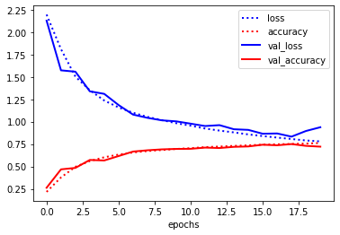

```
Model: "sequential_10"
_________________________________________________________________
Layer (type)                 Output Shape              Param #
=================================================================
reshape_5 (Reshape)          (None, 3072)              0
_________________________________________________________________
dense_25 (Dense)             (None, 100)               307300
_________________________________________________________________
dense_26 (Dense)             (None, 50)                5050
_________________________________________________________________
dense_27 (Dense)             (None, 25)                1275
_________________________________________________________________
dense_28 (Dense)             (None, 12)                312
_________________________________________________________________
dense_29 (Dense)             (None, 10)                130
=================================================================
Total params: 314,067
Trainable params: 314,067
Non-trainable params: 0
_________________________________________________________________
None
def build_model_1_1():
    model = models.Sequential()
    model.add(layers.Reshape((3072,), input_shape=(32,32,3)))
    model.add(layers.Dense(100, activation='relu'))
    model.add(layers.Dense(50, activation='relu'))
    model.add(layers.Dense(25, activation='relu'))
    model.add(layers.Dense(12, activation='relu'))
    model.add(layers.Dense(10, activation='softmax'))

    model.compile(optimizer='sgd',
                  loss='categorical_crossentropy',
                  metrics=['accuracy'])
    return model
```

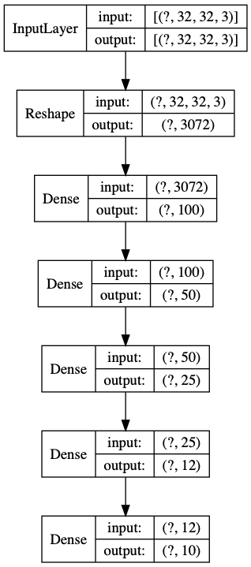

#### Answer 1.2, Preprocess (2p)

- Convert images to greyscale, other preprocessing optional.
  - Input shape should be (32,32,1)
- Explain design decisions. Is it better? Why (not)?
  - Color information is likely not so useful for classification. Greyscale makes the network smaller, less parameters to learn, less likely to overfit.

```
Since accuracy and learning curves are almost the same, then the color is not an important decision factor. Hence, the preprocessed version is preferred in further iterations, since the number of input features is smaller (length: 222)

Max val score: 74.66%
```

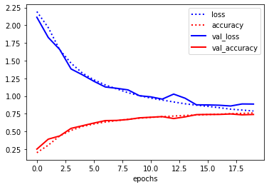

```
Model: "sequential_24"
_________________________________________________________________
Layer (type)                 Output Shape              Param #
=================================================================
reshape_19 (Reshape)         (None, 1024)              0
_________________________________________________________________
dense_95 (Dense)             (None, 100)               102500
_________________________________________________________________
dense_96 (Dense)             (None, 50)                5050
_________________________________________________________________
dense_97 (Dense)             (None, 25)                1275
_________________________________________________________________
dense_98 (Dense)             (None, 12)                312
_________________________________________________________________
dense_99 (Dense)             (None, 10)                130
=================================================================
Total params: 109,267
Trainable params: 109,267
Non-trainable params: 0
_________________________________________________________________
None
def build_model_1_2():
    model = models.Sequential()
    model.add(layers.Reshape((1024,), input_shape=(32,32,1)))
    model.add(layers.Dense(100, activation='relu'))
    model.add(layers.Dense(50, activation='relu'))
    model.add(layers.Dense(25, activation='relu'))
    model.add(layers.Dense(12, activation='relu'))
    model.add(layers.Dense(10, activation='softmax'))

    model.compile(optimizer='sgd',
                  loss='categorical_crossentropy',
                  metrics=['accuracy'])
    return model
```

#### Answer 1.3, Tune (4p)

- Regularize the model. What works best?
  - Should consider batch normalization, dropout, l1/l2 regularization (or Nesterov)
- Tune other hyperparameters (e.g. learning rate, batch size,...) as you see fit.
  - At least consider tuning learning rate, ideally also momentum, decay, other optimizers
- Explain your findings and final design decisions. Discuss the results.
  - Should be better, at least it shouldn't overfit

```
The number of epochs increased to 30, since the model could not converge as fast as before. To prevent overfitting, L1 and L2 regularization has been used. There has been no significant change in the learning curves, while accuracy dropped, so they were not used in the end. (length: 275)

Max val score: 85.40%
```

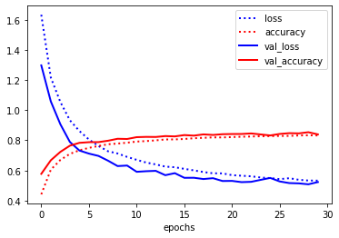

```
def build_model_1_3():
    model = models.Sequential()
    model.add(layers.Reshape((1024,), input_shape=(32,32,1)))
    model.add(layers.BatchNormalization())
    model.add(layers.Dense(100, activation='relu', kernel_initializer='he_normal'))
    model.add(layers.Dense(50, activation='relu', kernel_initializer='he_normal'))
    model.add(layers.Dense(25, activation='relu', kernel_initializer='he_normal'))
    model.add(layers.Dense(12, activation='relu', kernel_initializer='he_normal'))
    model.add(layers.Dense(10, activation='softmax', kernel_initializer='he_normal'))

    from tensorflow.keras.optimizers import Adam
    model.compile(optimizer=Adam(learning_rate=0.001),
                  loss='categorical_crossentropy',
                  metrics=['accuracy'])
    return model
```

#### Answer 2.1, ConvNet (7p)

- Build a sequential ConvNet, get at least 90% accuracy.
  - Conv2D layers, input shape (32,32,1)
  - Consider using blocks of Conv2D layers with maxpooling in between
  - Use zero-padding in Conv2D layers because the images are small
  - At least one dense hidden layer and dense output layer (sigmoid)
  - Consider adding batch normalization, dropout
  - Consider small dropout rates in beginning, larger dropout rates later in network
  - Consider other optimizers and tuning learning rate, momentum,...
- Explain what you did and why (800 chars). Is it working well?
  - Should be quite elaborate and sensible

[output not shown]

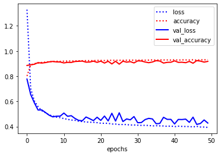

```
Model: "sequential_37"
_________________________________________________________________
Layer (type)                 Output Shape              Param #
=================================================================
conv2d_8 (Conv2D)            (None, 30, 30, 32)        320
_________________________________________________________________
batch_normalization_16 (Batc (None, 30, 30, 32)        128
_________________________________________________________________
max_pooling2d_4 (MaxPooling2 (None, 15, 15, 32)        0
_________________________________________________________________
conv2d_9 (Conv2D)            (None, 13, 13, 64)        18496
_________________________________________________________________
max_pooling2d_5 (MaxPooling2 (None, 6, 6, 64)          0
_________________________________________________________________
conv2d_10 (Conv2D)           (None, 4, 4, 128)         73856
_________________________________________________________________
conv2d_11 (Conv2D)           (None, 2, 2, 256)         295168
_________________________________________________________________
flatten_3 (Flatten)          (None, 1024)              0
_________________________________________________________________
dropout_2 (Dropout)          (None, 1024)              0
_________________________________________________________________
dense_160 (Dense)            (None, 256)               262400
_________________________________________________________________
dense_161 (Dense)            (None, 10)                2570
=================================================================
Total params: 652,938
Trainable params: 652,874
Non-trainable params: 64
_________________________________________________________________
None
def build_model_2_1():
  from tensorflow.keras import regularizers
  model = models.Sequential()
  model.add(layers.Conv2D(filters=32, kernel_size=(3, 3), activation='relu', kernel_initializer='he_normal', kernel_regularizer=regularizers.l2(0.001), input_shape=(32, 32, 1)))
  model.add(layers.BatchNormalization())
  model.add(layers.MaxPooling2D((2, 2), strides=2))
  model.add(layers.Conv2D(filters=64, kernel_size=(3, 3), activation='relu', kernel_initializer='he_normal', kernel_regularizer=regularizers.l2(0.001)))
  model.add(layers.MaxPooling2D((2, 2), strides=2))
  model.add(layers.Conv2D(filters=128, kernel_size=(3, 3), activation='relu', kernel_initializer='he_normal', kernel_regularizer=regularizers.l2(0.001)))
  model.add(layers.Conv2D(filters=256, kernel_size=(3, 3), activation='relu', kernel_initializer='he_normal', kernel_regularizer=regularizers.l2(0.001)))
  model.add(layers.Flatten())
  model.add(layers.Dropout(rate=0.3))
  model.add(layers.Dense(256, activation='relu', kernel_initializer='he_normal', kernel_regularizer=regularizers.l2(0.001)))
  model.add(layers.Dense(10, activation='softmax', kernel_initializer='he_normal', kernel_regularizer=regularizers.l2(0.001)))

  from tensorflow.keras.optimizers import Adam
  model.compile(optimizer=Adam(learning_rate=0.001),
                loss='categorical_crossentropy',
                metrics=['accuracy'])
  return model
```

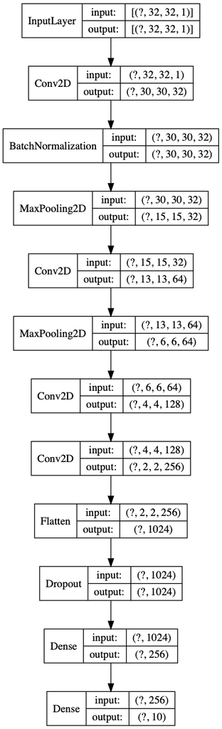

#### Answer 2.2, Data Augmentation (3p)

- Augment the preprocessed training data.
  - Use small variations (small shifts up-down, left-right) of flips becasue the images are small
  - Large shifts and rotations distort the image too much
- Explain what you did and why. Discuss the performance of the model.

[output not shown]

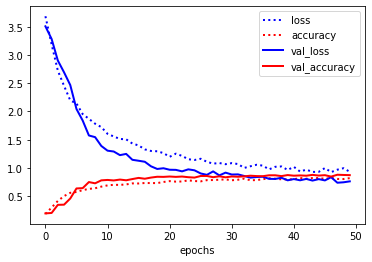

```
datagen = ImageDataGenerator(
    width_shift_range=0.1,
    height_shift_range=0.1,
    rotation_range=30
    )
```

#### Answer 3.1, Misclassifications (2p)

[output not shown]

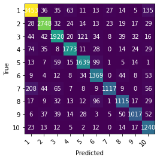

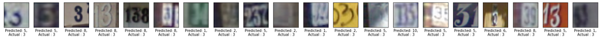

#### Answer 3.2, Activations (4p)

- Retrieve and visualize the activations for one example
- For every filter for different convolutional layers (at different depths in the network).
- Give an explanation. Is your model indeed learning something useful?
  - Should detect edges etc in first layers, higher-order object (e.g. interesting regions) in deeper layers.

[output not shown]

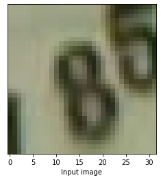

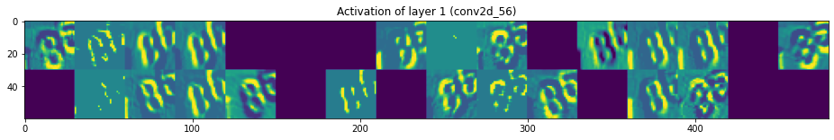

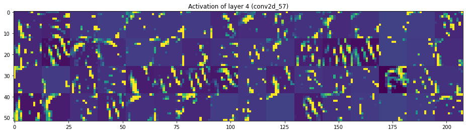

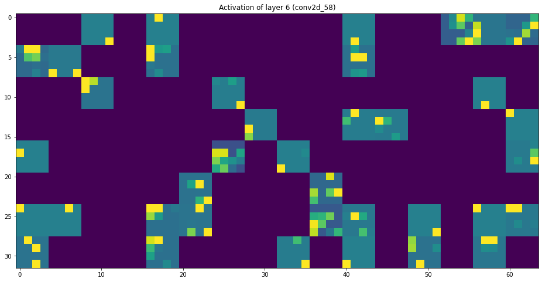

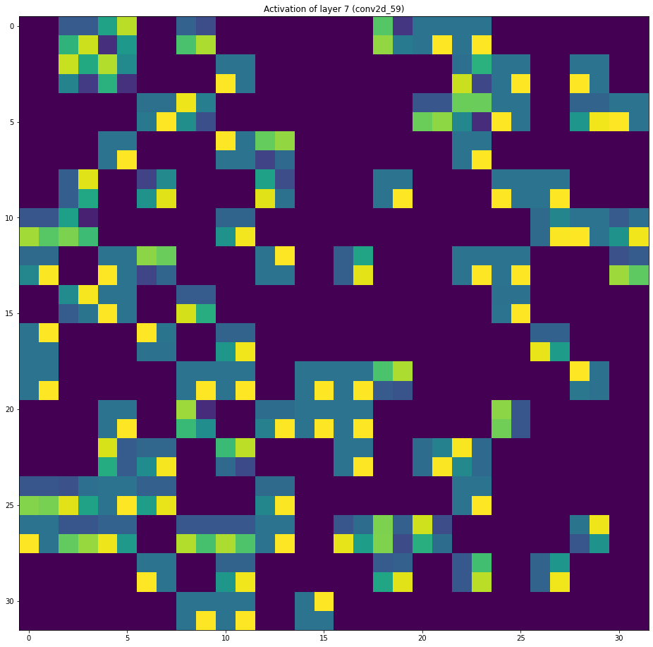

```
Showing only the most interesting activations
```

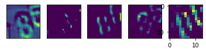

#### Answer 3.3, Class activation map (4p)

- Show a class activation map for your last convolutional layer
- Superimpose the activation map over the image, or plot side by side
  - Should make sense, detect interesting regions to classify the number

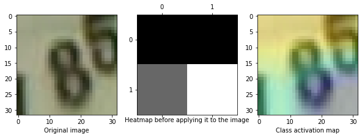

```
def plot_activation_map():
  from tensorflow.keras import backend as K

  img_tensor = X_test_g[0]
  img_tensor = np.expand_dims(img_tensor, axis=0)

  layer_outputs = [layer.output for layer in trained_model.layers[:7]]

  layer_names = [layer.name for layer in trained_model.layers[:7]]

  last_conv_layer = trained_model.get_layer(layer_names[-1])

  # Compute the gradients for the last conv layer
  with tf.GradientTape() as tape:
    activation_model = models.Model(inputs=trained_model.input, outputs=layer_outputs)
    activation = activation_model.output[:7]
    grads = tape.gradient(activation, last_conv_layer.output)

  pooled_grads = K.mean(grads, axis=(0, 1, 2))

  iterate = K.function([trained_model.input], [pooled_grads, last_conv_layer.output[0]])

  pooled_grads_value, conv_layer_output_value = iterate([img_tensor])

  for i in range(256):
    conv_layer_output_value[:, :, i] *= pooled_grads_value[i]

  heatmap = np.mean(conv_layer_output_value, axis=-1)
  heatmap = np.maximum(heatmap, 0)
  max_heat = np.max(heatmap)
  heatmap /= max_heat

  # Plot the original image, the heatmap and class activation map
  f, (a1, a2, a3) = plt.subplots(1, 3, figsize=(10, 10))
  a1.imshow(X_test[0])
  a1.set_xlabel("Original image")
  a2.matshow(heatmap, cmap='gray')
  a2.set_xlabel("Heatmap before applying it to the image")
  a3.imshow(apply_heatmap(X_test[0], heatmap))
  a3.set_xlabel("Class activation map")

  plt.show()
```

#### Answer 4.1, Fast feature extraction (5p)

- Import the VGG16 model, pretrained on ImageNet
- Freeze convolutional base, adds a dense layer
- Consider unfreezing the last few convolutional layers and evaluate whether that works better
  - Check if they do. It is very likely to help.
- Discuss the observed performance
  - Should get around 80% accuracy

[output not shown]

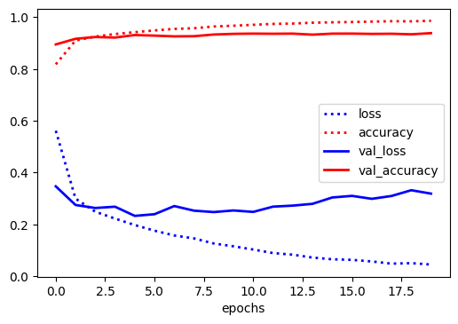

```
Model: "sequential_57"
_________________________________________________________________
Layer (type)                 Output Shape              Param #
=================================================================
vgg16 (Model)                (None, 1, 1, 512)         14714688
_________________________________________________________________
flatten_22 (Flatten)         (None, 512)               0
_________________________________________________________________
dense_203 (Dense)            (None, 256)               131328
_________________________________________________________________
dense_204 (Dense)            (None, 10)                2570
=================================================================
Total params: 14,848,586
Trainable params: 3,969,034
Non-trainable params: 10,879,552
_________________________________________________________________
None
def build_model_4_1():
  from tensorflow.keras.applications.vgg16 import VGG16

  conv_base = VGG16(weights='imagenet',
                  include_top=False,
                  input_shape=(32, 32, 3))

  model = models.Sequential()
  model.add(conv_base)
  model.add(layers.Flatten())
  model.add(layers.Dense(256, activation='relu'))
  model.add(layers.Dense(10, activation='softmax'))

  for layer in conv_base.layers:
    if layer.name == 'block5_conv1' or layer.name == 'block4_conv1' or layer.name == 'block3_conv1':
        layer.trainable = True
    else:
        layer.trainable = False

  from tensorflow.keras.optimizers import Adam
  model.compile(optimizer=Adam(learning_rate=0.001),
                loss='categorical_crossentropy',
                metrics=['accuracy'])

  return model
```

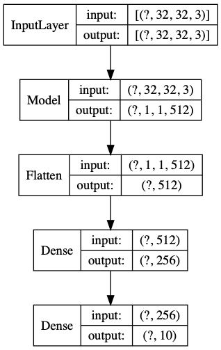

#### Answer 4.2, Embeddings (5p)

- Generate embeddings with the trained convolutional part of model_4_1 (without the dense layer)
- Embed the training and test data and store them to disk
- Build and evaluate a pipeline on the embedded data
  - Check if pipeline makes sense (e.g. use models that can handle many dimensions)
- Describe what you did and what you observed (max 800 chars).
  - Consider different models, preprocessing, tuning, etc.
  - Check performance (see original Submission.html) when in doubt. We did not run all the evaluations because it takes too long, and the output is ill-defined.

[output not shown]

```
Running time: 13.21 seconds
Last modified: May 26, 2020
scikit-learn version: 0.23.1
```